# Data Visualization using ggplot2

# Coordinate Systems

- The next term from the Grammar of Graphics that can be specified is the Coordinate system. As with scales, coordinate systems are specified with functions that all start with coord_ and are added as a layer. There are a number of different possible coordinate systems to use, including:
- coord_cartesian the default cartesian coordinate system, where you specify x and y values (e.g. allows you to zoom in or out).
- coord_flip a cartesian system with the x and y flipped
- coord_fixed a cartesian system with a “fixed” aspect ratio (e.g., 1.78 for a “widescreen” plot)
- coord_polar a plot using polar coordinates
- coord_quickmap a coordinate system that approximates a good aspect ratio for maps. See documentation for more details.

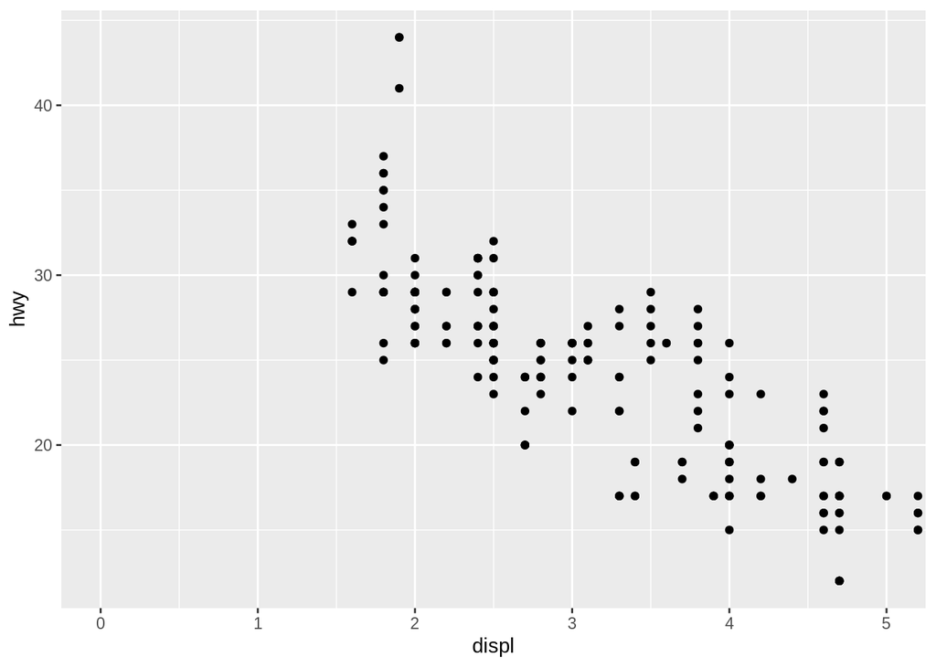

```r
# zoom in with coord_cartesian
ggplot(mpg, aes(x = displ, y = hwy)) +
  geom_point() +
  coord_cartesian(xlim = c(0, 5))
```

- You can even use polar coordinates!

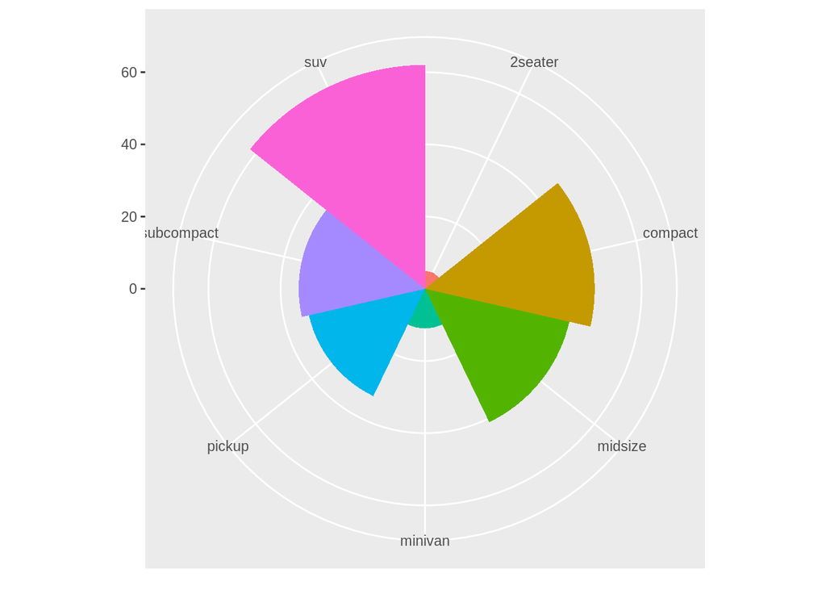

```r
bar <- ggplot(data = mpg) +
  geom_bar(mapping = aes(x = class, fill = class), show.legend = FALSE,width = 1) +
  theme(aspect.ratio = 1) +
  labs(x = NULL, y = NULL)

# bar + coord_flip()
bar + coord_polar()
```

# Facets

- Facets are ways of grouping a data plot into multiple different pieces (subplots). This allows you to view a separate plot for each value in a categorical variable. You can construct a plot with multiple facets by using the facet_wrap() function. This will produce a “row” of subplots, one for each categorical variable (the number of rows can be specified with an additional argument):

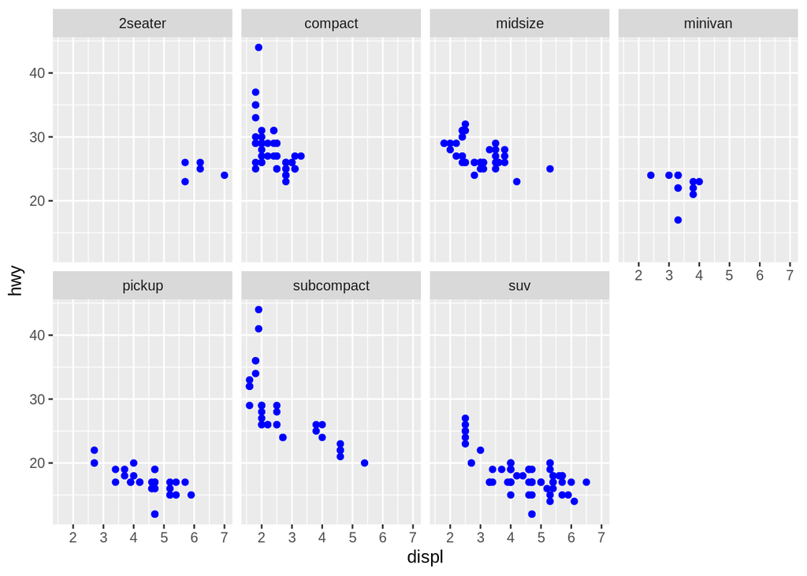

```r
ggplot(mpg, aes(x = displ, y = hwy)) +
  geom_point(colour="blue") +
  facet_wrap(~ class, nrow=2)
```

- You can also facet_grid to facet your data by more than one categorical variable. Note that we use a tilde (~) in our facet functions. With facet_grid the variable to the left of the tilde will be represented in the rows and the variable to the right will be represented across the columns.

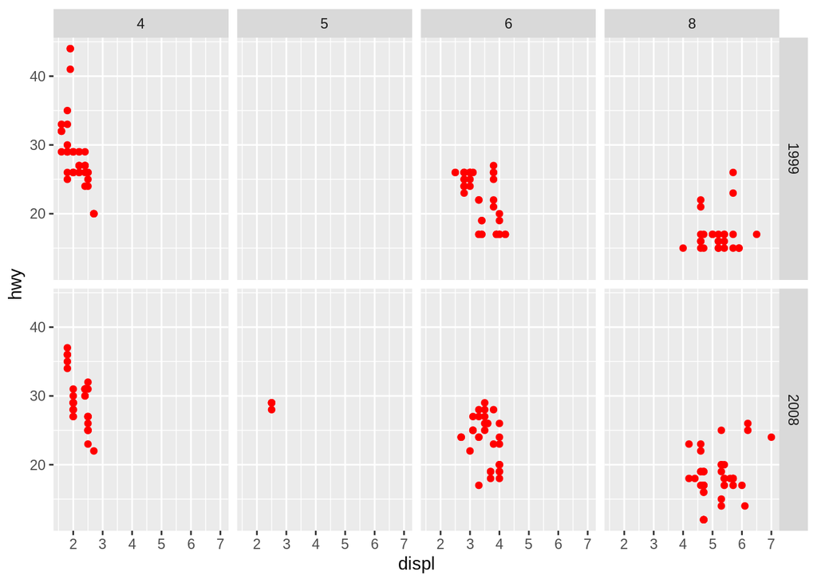

```r
ggplot(mpg, aes(x = displ, y = hwy)) +
  geom_point(color="red") +
  facet_grid(year ~ cyl)
```

# Labels & Annotations

- Textual labels and annotations (on the plot, axes, geometry, and legend) are an important part of making a plot understandable and communicating information. ggplot makes it easy to add such annotations.
- You can add titles and axis labels to a chart using the labs() function (not labels, which is a different R function!):

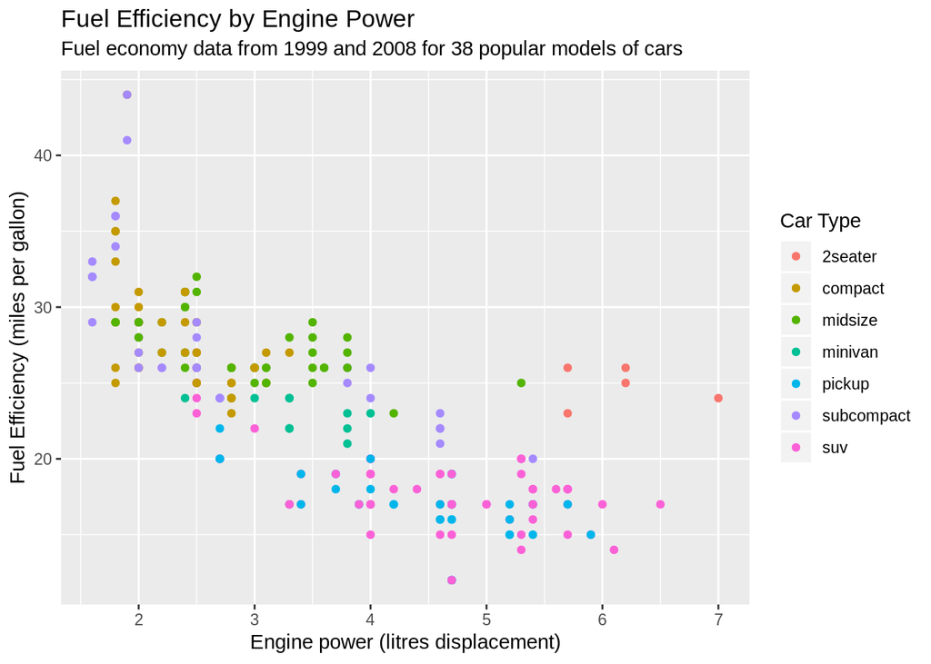

```r
ggplot(mpg, aes(x = displ, y = hwy, color = class)) +
  geom_point() +
  labs(title = "Fuel Efficiency by Engine Power",
       subtitle = "Fuel economy data from 1999 and 2008 for 38 popular models of cars",
       x = "Engine power (litres displacement)",
       y = "Fuel Efficiency (miles per gallon)",
       color = "Car Type")
```

- Adding theme

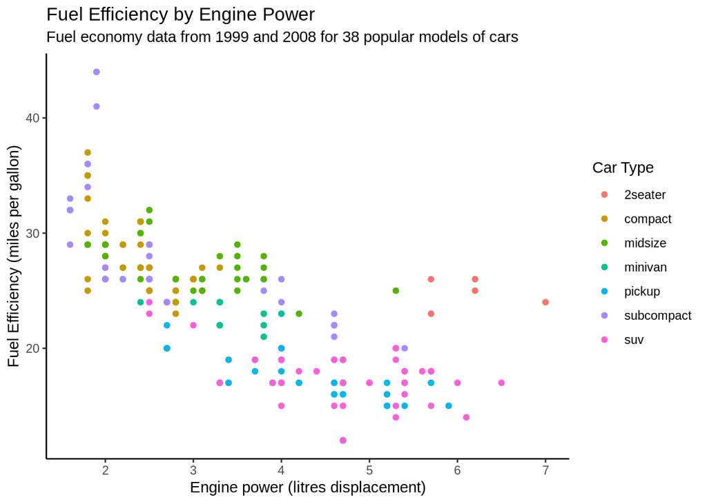

```r
ggplot(mpg, aes(x = displ, y = hwy, color = class)) +
  geom_point() +
  labs(title = "Fuel Efficiency by Engine Power",
       subtitle = "Fuel economy data from 1999 and 2008 for 38 popular models of cars",
       x = "Engine power (litres displacement)",
       y = "Fuel Efficiency (miles per gallon)",
       color = "Car Type") +
      theme_classic()
```

### References

- https://r4ds.had.co.nz/data-visualisation.html#introduction-1